# Practical Machine Learning : Prediction Assignment

Ribhav

20/10/2020

## Intro

Using devices such as Jawbone Up, Nike FuelBand, and Fitbit it is now possible to collect a large amount of data about personal activity relatively inexpensively. These type of devices are part of the quantified self movement – a group of enthusiasts who take measurements about themselves regularly to improve their health, to find patterns in their behavior, or because they are tech geeks. One thing that people regularly do is quantify how much of a particular activity they do, but they rarely quantify how well they do it. In this project, your goal will be to use data from accelerometers on the belt, forearm, arm, and dumbell of 6 participants. They were asked to perform barbell lifts correctly and incorrectly in 5 different ways. More information is available from the website here: http://web.archive.org/web/20161224072740/http:/groupware.les.inf.puc-rio.br/har

## Data

for training dataset, Check out the below link for Training Data of the project https://d396qusza40orc.cloudfront.net/predmachlearn/pml-training.csv

for test data too Check out the link for Testing data of the project. https://d396qusza40orc.cloudfront.net/predmachlearn/pml-testing.csv

## Understanding Data

```r
testData<-read.csv("pml-testing.csv")
trainData<-read.csv("pml-training.csv")
dim(trainData)
```

```
## [1] 19622   160
```

There are 160 variables and 19622 observations in the training set given.

## Data cleaning

In this training dataset, most of the variables have missing values and therefore we need to clean our data.

```r
#First loading the necessary libraries for cleaning and rest of the prediction.
library(caret)
library(rpart)
library(rpart.plot)
library(rattle)
library(randomForest)
library(corrplot)
library(caTools)
library(e1071)
library(Amelia)
```

### Splitting the data into train and test sets.

```r
set.seed(222)
sampleData<-sample.split(trainData$classe,SplitRatio = 0.8)
trainSet<-subset(trainData,sampleData==TRUE)
testSet<-subset(trainData,sampleData==FALSE)
dim(trainSet)
```

```
## [1] 15699   160
```

```r
dim(testSet)
```

```
## [1] 3923  160
```

### Removing variables with low variance

```r
nearZero <- nearZeroVar(trainData)
trainSet <- trainSet[, -nearZero]
testSet  <- testSet[, -nearZero]
dim(trainSet)
```

```
## [1] 15699   100
```

```r
dim(testSet)
```

```
## [1] 3923  100
```

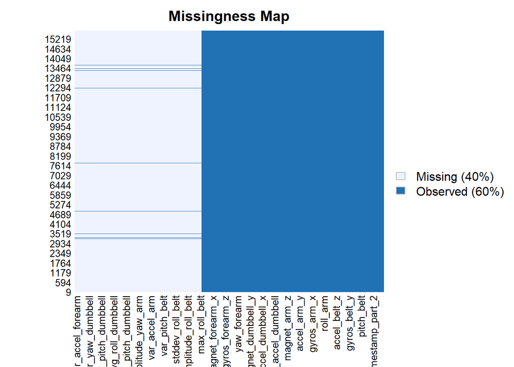

```r
# Missing data check
missmap(trainSet)
```

To get a proper predictive model, we need to delete the missing and insignificant data values.

### Removing missing(NA) values

```r
missingvalues   <- sapply(trainSet, function(x) mean(is.na(x))) > 0.95
trainSet <- trainSet[, missingvalues==FALSE]
testSet  <- testSet[, missingvalues==FALSE]
dim(trainSet)
```

```
## [1] 15699    59
```

```r
dim(testSet)
```

```
## [1] 3923   59
```

### Remove identical variables

```r
trainSet <- trainSet[, -(1:5)]
testSet  <- testSet[, -(1:5)]
dim(trainSet)
```

```
## [1] 15699    54
```

```r
dim(testSet)
```

```
## [1] 3923   54
```

Now that we are left with the proper values to help us build the model, we also need to check the correlationData between the variables

###Checking the Missing data in the new cleaned data

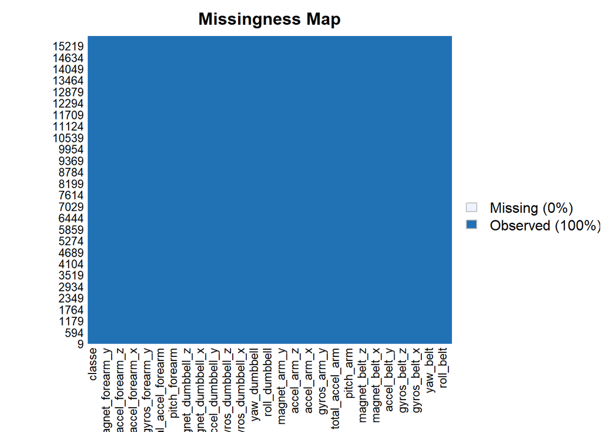

```r
missmap(trainSet)
```

Since we do not have any missing data we can continue to build the model after checking for correlationData.

### Null Hypothesis

NullHyp<-lm(classe~., data=trainSet)

summary(NullHyp)

## correlationData in variables

in trainset plotting the correlationData

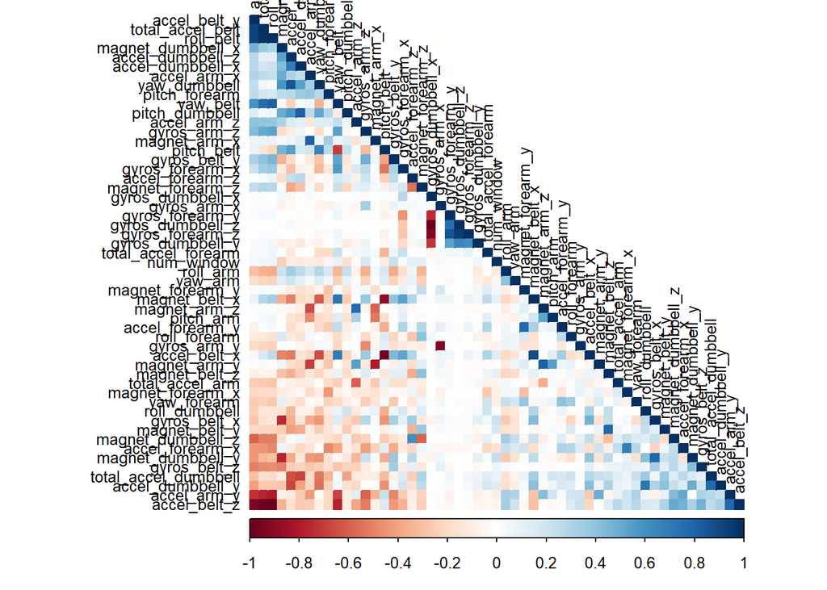

```r
correlationData<-cor(trainSet[, -length(names(trainSet))])
corrplot(correlationData, order = "FPC", method = "color", type = "lower",
         tl.cex = 0.8, tl.col = rgb(0, 0, 0))
```

The dark colors in the graph above represents the highly correlated variables.

# Model test for prediction

## A) Decision Tree Model Prediction

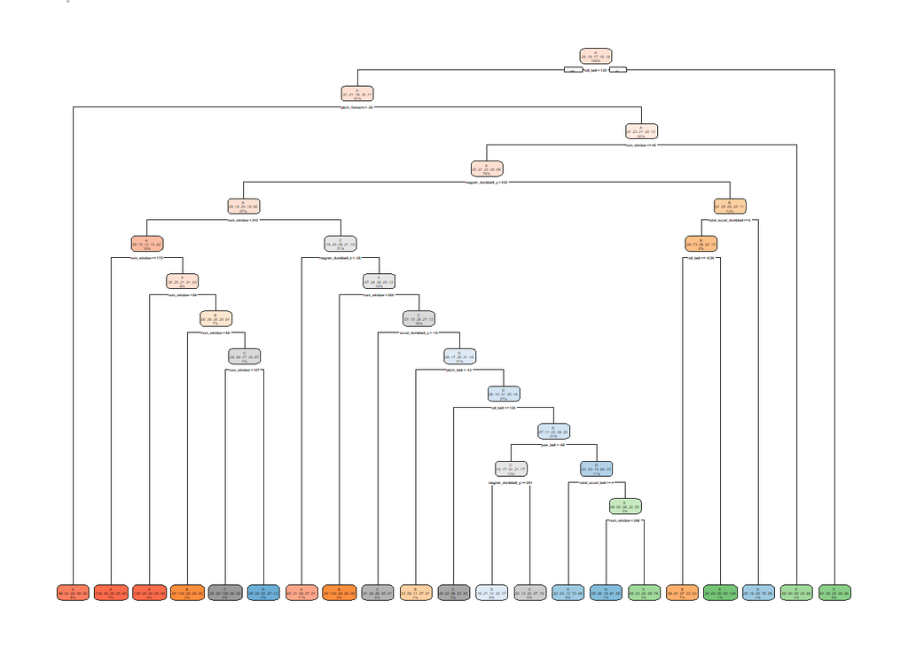

```r
TreeData<-rpart(classe~.,trainSet,method="class")
rpart.plot(TreeData)
```

```r
# Predicting testset result using the above model
predictionData<-predict(TreeData, newdata=testSet,type="class")
confusionMat<-confusionMatrix(predictionData,testSet$classe)
confusionMat
```

```
## Confusion Matrix and Statistics
##
##           Reference
## Prediction   A   B   C   D   E
##          A 976 121  30  26   6
##          B  55 491  40  23  16
##          C   5  44 532  29  48
##          D  53 101  82 527 124
##          E  27   2   0  38 527
##
## Overall Statistics
##
##                Accuracy : 0.7782
##                  95% CI : (0.7649, 0.7911)
##     No Information Rate : 0.2845
##     P-Value [Acc > NIR] : < 2.2e-16
##
##                   Kappa : 0.7196
##
##  Mcnemar's Test P-Value : < 2.2e-16
##
## Statistics by Class:
##
##                      Class: A Class: B Class: C Class: D Class: E
## Sensitivity            0.8746   0.6469   0.7778   0.8196   0.7309
## Specificity            0.9348   0.9576   0.9611   0.8902   0.9791
## Pos Pred Value         0.8421   0.7856   0.8085   0.5941   0.8872
## Neg Pred Value         0.9493   0.9187   0.9534   0.9618   0.9417
## Prevalence             0.2845   0.1935   0.1744   0.1639   0.1838
## Detection Rate         0.2488   0.1252   0.1356   0.1343   0.1343
## Detection Prevalence   0.2954   0.1593   0.1677   0.2261   0.1514
## Balanced Accuracy      0.9047   0.8023   0.8694   0.8549   0.8550
```

## B) Random Forest Model Prediction

ForestData<- trainControl(method=“cv”, number=3, verboseIter=FALSE)

forestmodeldata <- train(classe ~ ., data=trainSet, method=“rf”, trControl=ForestData)

forestmodeldata$finalModel

forestPrediction <- predict(forestmodeldata , newdata=testSet)

forestConfusionMat<-confusionMatrix(forestPrediction,testSet$classe)

# Applying Approriate Model to the Test Dataset

```r
# As the Random Forest model is appropriate to use but due to the very sluggish rendering of the results with not so compatible system RAM, I am predicting the results using the Decision Tree Model
predictTestResults<-predict(TreeData,newdata=testData, type="class" )
predictTestResults
```

```
##  1  2  3  4  5  6  7  8  9 10 11 12 13 14 15 16 17 18 19 20
##  B  A  A  A  A  C  D  D  A  A  C  D  B  A  D  E  A  A  B  B
## Levels: A B C D E
```